# AI Advice – Pretest Analysis

Evaluation of AI justifications

Author

Ceren Ay

Published

September 22, 2026

## 1 About this document

NOTE: Used Claude Cowork a bit in this file to organize the results and visualize better(can be discussed how well it worked).

This file analyses the **pretest** of the AI-advice experiment. After reading the allocation task (dictator game with a taking option: decision-maker has £10, recipient has £4), participants saw three AI responses that all recommend *“give £3 to the recipient”* but differ in the **evaluative standard** and justification:

| Condition | Evaluative standard | Justification (short) |
| --- | --- | --- |
| `equal` | Equality | Both end up with £7; upholds the principle of equality |
| `fair` | Fairness | Both end up with £7; aligns with the principle of fairness |
| `fairequal` | Fairness and Equality | Both end up with £7; promotes fairness and equality |

Each response was rated (within subjects, block order randomised by Qualtrics) on three 5-point Likert items (1 = Strongly disagree … 5 = Strongly agree):

1. **Standard matters** – “The recommendation is based on a standard that matters to me”
2. **Reasoning makes sense** – “The reasoning behind this recommendation makes sense to me”
3. **Inclined to revise** – “After reading this response, I feel more inclined to revise my allocation decision”

```r
required <- c("tidyverse", "lme4", "lmerTest", "emmeans", "ordinal", "knitr")
missing  <- required[!vapply(required, requireNamespace, logical(1), quietly = TRUE)]
if (length(missing)) stop("Please install: ", paste(missing, collapse = ", "),
                          "\n  install.packages(c(\"", paste(missing, collapse = "\", \""), "\"))")

suppressPackageStartupMessages({
  library(tidyverse)
  library(lme4)
  library(lmerTest)
  library(emmeans)
  library(knitr)
})

# ---- Labels (edit here if conditions/items change) -------------------------
advice_labels <- c(
  equal     = "Equality",
  fair      = "Fairness",
  fairequal = "Fairness & Equality"
)
item_labels <- c(
  "1" = "Standard matters",
  "2" = "Reasoning makes sense",
  "3" = "Inclined to revise"
)
likert_levels <- c("Strongly disagree", "Somewhat disagree",
                   "Neither agree nor disagree", "Somewhat agree", "Strongly agree")

# Qualtrics block IDs of the randomised advice blocks (used only if the
# randomisation order is exported, see the "Order effects" section)
block_to_advice <- c(
  "BL_3Vona5LNo1cvl0q" = "equal",     "AI advice 1" = "equal",
  "BL_7QbYfICheXo8su2" = "fair",      "AI advice 2" = "fair",
  "BL_3xC1DEX1CbvBK62" = "fairequal", "AI advice 3" = "fairequal"
)

# Correct answers of the comprehension checks (amount in £)
correct_q5 <- 4   # Q5: most you can take
correct_q6 <- 0   # Q6: least you can give

# ---- Plot style -------------------------------------------------------------
pal_advice <- c("#2a78d6", "#eb6834", "#1baf7a")          # fixed categorical order
pal_likert <- c("#c73a39", "#f0a19e", "#cfcdc8", "#8db6ea", "#2a78d6")  # diverging, gray midpoint
names(pal_likert) <- likert_levels

theme_set(
  theme_minimal(base_size = 12) +
    theme(panel.grid.minor = element_blank(),
          panel.grid.major.y = element_line(colour = "grey90", linewidth = 0.3),
          panel.grid.major.x = element_blank(),
          strip.text = element_text(face = "bold", hjust = 0),
          legend.position = "bottom",
          plot.title.position = "plot")
)

if (params$save_outputs) dir.create("output", showWarnings = FALSE)
```

## 2 Data import

```r
read_qualtrics <- function(path) {
  hdr <- names(read_csv(path, n_max = 0, show_col_types = FALSE))
  dat <- read_csv(path, col_names = hdr, skip = 1, col_types = cols(.default = "c"),
                  show_col_types = FALSE)
  # Drop Qualtrics' extra header rows (question text + ImportId rows)
  dat <- dat |>
    filter(!(StartDate %in% c("Start Date", "StartDate")),
           !str_detect(StartDate, fixed("ImportId")))
  # Clean names: Qualtrics adds spaces, e.g. "advice_equal _1" -> "advice_equal_1"
  names(dat) <- str_replace_all(names(dat), "\\s+", "")
  dat |> mutate(source_file = basename(path))
}

files <- list.files(params$data_dir, pattern = "\\.csv$", full.names = TRUE)
if (length(files) == 0) stop("No CSV files found in ", params$data_dir)

raw <- map(files, read_qualtrics) |>
  list_rbind() |>
  distinct(ResponseId, .keep_all = TRUE) |>
  mutate(Duration = as.numeric(`Duration(inseconds)`),
         Progress = as.numeric(Progress),
         Finished = as.logical(toupper(Finished)),
         StartDate = ymd_hms(StartDate, quiet = TRUE))

tibble(file = basename(files)) |> kable(col.names = "Files read")
```

| Files read |
| --- |
| AI Advice_September 21, 2026_03.55.csv |

```r
cat("Rows read (after de-duplication):", nrow(raw), "\n")
```

```
Rows read (after de-duplication): 35
```

## 3 Sample and exclusions

Responses are excluded step by step: survey previews / tests, incomplete responses, failed comprehension checks (if `exclude_failed_checks = TRUE`), missing advice ratings, and speeders (if `exclude_speeders = TRUE`). Duplicate IP addresses are flagged.

```r
check_amount <- function(x) {
  x <- str_trim(x)
  case_when(x == "1" ~ 0, x == "2" ~ 4, x == "3" ~ 10,
            TRUE ~ suppressWarnings(as.numeric(str_extract(x, "\\d+"))))
}

advice_cols <- str_subset(names(raw), "^advice_.+_\\d+$")

d <- raw |>
  mutate(
    is_preview   = Status %in% c("Survey Preview", "1", "Survey Test", "2") |
                   DistributionChannel %in% c("preview", "test"),
    check_take   = check_amount(Q5) == correct_q5,
    check_give   = check_amount(Q6) == correct_q6,
    checks_pass  = coalesce(check_take & check_give, FALSE),
    has_ratings  = rowSums(!is.na(across(all_of(advice_cols)))) == length(advice_cols),
    dup_ip       = !is.na(IPAddress) & (duplicated(IPAddress) | duplicated(IPAddress, fromLast = TRUE))
  )

med_dur <- median(d$Duration[!d$is_preview & d$Finished], na.rm = TRUE)
d <- d |> mutate(speeder = Duration < params$speeder_cutoff * med_dur)

steps <- list(
  "All recorded responses"                 = rep(TRUE, nrow(d)),
  "Not a preview/test"                     = !d$is_preview,
  "Finished"                               = d$Finished,
  "Passed comprehension checks"            = if (params$exclude_failed_checks) d$checks_pass else rep(TRUE, nrow(d)),
  "All advice ratings present"             = d$has_ratings,
  "Not a speeder"                          = if (params$exclude_speeders) !d$speeder else rep(TRUE, nrow(d))
)
keep <- Reduce(`&`, steps, accumulate = TRUE)
tibble(step = names(steps),
       n_remaining = map_int(keep, sum),
       excluded = c(0, -diff(map_int(keep, sum)))) |>
  kable(col.names = c("Step", "N remaining", "Excluded at this step"))
```

| Step | N remaining | Excluded at this step |
| --- | --- | --- |
| All recorded responses | 35 | 0 |
| Not a preview/test | 29 | 6 |
| Finished | 29 | 0 |
| Passed comprehension checks | 29 | 0 |
| All advice ratings present | 29 | 0 |
| Not a speeder | 29 | 0 |

```r
d_clean <- d[keep[[length(keep)]], ]
N <- nrow(d_clean)
```

**Analysis sample: N = 29.**

```r
d_real <- d |> filter(!is_preview, Finished)
tibble(
  Indicator = c("Comprehension check 1 (take £4) correct",
                "Comprehension check 2 (give £0) correct",
                "Both checks correct",
                sprintf("Speeders (< %.0f%% of median duration = %.0f s)",
                        100 * params$speeder_cutoff, params$speeder_cutoff * med_dur),
                "Duplicate IP address"),
  n = c(sum(d_real$check_take, na.rm = TRUE), sum(d_real$check_give, na.rm = TRUE),
        sum(d_real$checks_pass), sum(d_real$speeder, na.rm = TRUE), sum(d_real$dup_ip)),
  pct = round(100 * n / nrow(d_real), 1)
) |> kable(col.names = c("Indicator (non-preview, finished)", "n", "%"))
```

| Indicator (non-preview, finished) | n | % |
| --- | --- | --- |
| Comprehension check 1 (take £4) correct | 29 | 100 |
| Comprehension check 2 (give £0) correct | 29 | 100 |
| Both checks correct | 29 | 100 |
| Speeders (< 33% of median duration = 56 s) | 0 | 0 |
| Duplicate IP address | 0 | 0 |

```r
att <- d_clean |> select(any_of(c("attempts_take", "attempts_give")))
if (ncol(att) && any(!is.na(att))) {
  att |> mutate(across(everything(), as.numeric)) |>
    pivot_longer(everything()) |> count(name, value) |> kable()
} else {
  cat("Note: embedded data 'attempts_take' / 'attempts_give' are empty in this export.\n")
}
```

```
Note: embedded data 'attempts_take' / 'attempts_give' are empty in this export.
```

```
   Min. 1st Qu.  Median    Mean 3rd Qu.    Max.
   1.32    2.20    2.85    3.09    3.58    6.78
```

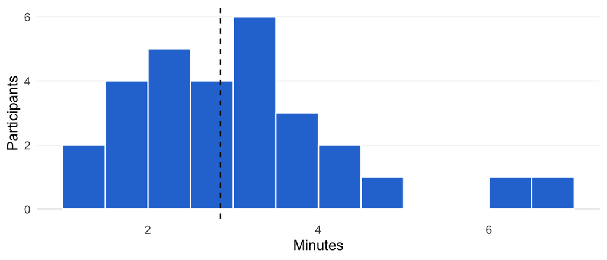

Figure 1: Completion time (analysis sample). Dashed line = median.

```r
ggplot(d_clean, aes(Duration / 60)) +
  geom_histogram(binwidth = 0.5, boundary = 0, fill = pal_advice[1], colour = "white") +
  geom_vline(xintercept = median(d_clean$Duration) / 60, linetype = "dashed") +
  labs(x = "Minutes", y = "Participants")

summary(d_clean$Duration / 60) |> round(2)
```

## 4 Reshaping to long format

```r
to_score <- function(x) {
  x <- str_trim(x)
  num <- suppressWarnings(as.numeric(x))
  ifelse(!is.na(num), num, match(tolower(x), tolower(likert_levels)))
}

long <- d_clean |>
  select(ResponseId, all_of(advice_cols)) |>
  pivot_longer(-ResponseId, names_to = "var", values_to = "response") |>
  mutate(
    advice_code = str_match(var, "^advice_(.+)_(\\d+)$")[, 2],
    item_code   = str_match(var, "^advice_(.+)_(\\d+)$")[, 3],
    score       = to_score(response),
    advice = coalesce(advice_labels[advice_code], str_to_title(advice_code)),
    advice = factor(advice, levels = unique(c(advice_labels, sort(unique(advice))))),
    advice = droplevels(advice),
    item   = factor(coalesce(item_labels[item_code], paste("Item", item_code)),
                    levels = unique(c(item_labels, paste("Item", sort(unique(item_code)))))),
    item   = droplevels(item),
    response_lbl = factor(likert_levels[score], levels = likert_levels),
    id = factor(ResponseId)
  )

if (any(is.na(long$score))) warning("Some Likert responses could not be converted to numbers.")
pal_adv <- setNames(rep_len(pal_advice, nlevels(long$advice)), levels(long$advice))

head(long |> select(ResponseId, advice, item, response, score), 6)
```

| ResponseId | advice | item | response | score |
| --- | --- | --- | --- | --- |
| R_8lxFYK2PYy61bmj | Equality | Standard matters | Strongly agree | 5 |
| R_8lxFYK2PYy61bmj | Equality | Reasoning makes sense | Strongly agree | 5 |
| R_8lxFYK2PYy61bmj | Equality | Inclined to revise | Somewhat agree | 4 |
| R_8lxFYK2PYy61bmj | Fairness | Standard matters | Strongly agree | 5 |
| R_8lxFYK2PYy61bmj | Fairness | Reasoning makes sense | Strongly agree | 5 |
| R_8lxFYK2PYy61bmj | Fairness | Inclined to revise | Somewhat agree | 4 |

## 5 Descriptive statistics

```r
desc <- long |>
  group_by(item, advice) |>
  summarise(n = sum(!is.na(score)),
            mean = mean(score, na.rm = TRUE),
            sd = sd(score, na.rm = TRUE),
            median = median(score, na.rm = TRUE),
            pct_agree = 100 * mean(score >= 4, na.rm = TRUE),
            pct_disagree = 100 * mean(score <= 2, na.rm = TRUE),
            .groups = "drop")
desc |> kable(digits = c(0, 0, 0, 2, 2, 1, 1, 1),
              col.names = c("Item", "Advice", "n", "Mean", "SD", "Median", "% agree", "% disagree"))
```

Table 1: Ratings by advice and item (1 = Strongly disagree, 5 = Strongly agree). % agree = Somewhat/Strongly agree; % disagree = Somewhat/Strongly disagree.

| Item | Advice | n | Mean | SD | Median | % agree | % disagree |
| --- | --- | --- | --- | --- | --- | --- | --- |
| Standard matters | Equality | 29 | 4.41 | 0.82 | 5 | 93.1 | 6.9 |
| Standard matters | Fairness | 29 | 4.34 | 1.08 | 5 | 89.7 | 6.9 |
| Standard matters | Fairness & Equality | 29 | 4.55 | 0.74 | 5 | 93.1 | 3.4 |
| Reasoning makes sense | Equality | 29 | 4.83 | 0.38 | 5 | 100.0 | 0.0 |
| Reasoning makes sense | Fairness | 29 | 4.72 | 0.53 | 5 | 96.6 | 0.0 |
| Reasoning makes sense | Fairness & Equality | 29 | 4.79 | 0.41 | 5 | 100.0 | 0.0 |
| Inclined to revise | Equality | 29 | 3.55 | 1.30 | 4 | 58.6 | 20.7 |
| Inclined to revise | Fairness | 29 | 3.34 | 1.26 | 4 | 55.2 | 27.6 |
| Inclined to revise | Fairness & Equality | 29 | 3.34 | 1.23 | 4 | 51.7 | 24.1 |

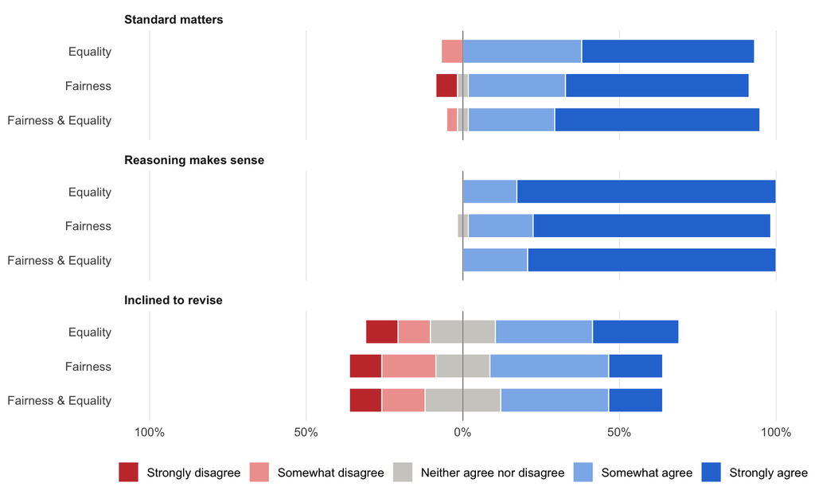

Figure 2: Distribution of responses. Bars are centred on the neutral category: disagreement to the left, agreement to the right.

```r
lik <- long |>
  count(item, advice, response_lbl, .drop = FALSE) |>
  group_by(item, advice) |>
  mutate(pct = 100 * n / sum(n)) |>
  ungroup() |>
  mutate(pct_plot = case_when(
    as.integer(response_lbl) < 3  ~ -pct,
    as.integer(response_lbl) == 3 ~ -pct / 2,
    TRUE ~ pct))
neutral_right <- lik |> filter(as.integer(response_lbl) == 3) |> mutate(pct_plot = pct / 2)
lik_plot <- bind_rows(lik, neutral_right)

ggplot(lik_plot, aes(x = pct_plot, y = fct_rev(advice), fill = response_lbl)) +
  geom_col(data = filter(lik_plot, pct_plot < 0),
           position = position_stack(reverse = FALSE), width = 0.7, colour = "white", linewidth = 0.4) +
  geom_col(data = filter(lik_plot, pct_plot >= 0),
           position = position_stack(reverse = TRUE), width = 0.7, colour = "white", linewidth = 0.4) +
  geom_vline(xintercept = 0, colour = "grey40", linewidth = 0.3) +
  facet_wrap(~ item, ncol = 1) +
  scale_fill_manual(values = pal_likert, drop = FALSE, name = NULL,
                    breaks = likert_levels) +
  scale_x_continuous(labels = \(x) paste0(abs(x), "%"), limits = c(-100, 100)) +
  labs(x = NULL, y = NULL) +
  guides(fill = guide_legend(nrow = 1)) +
  theme(panel.grid.major.y = element_blank(),
        panel.grid.major.x = element_line(colour = "grey90", linewidth = 0.3))
```

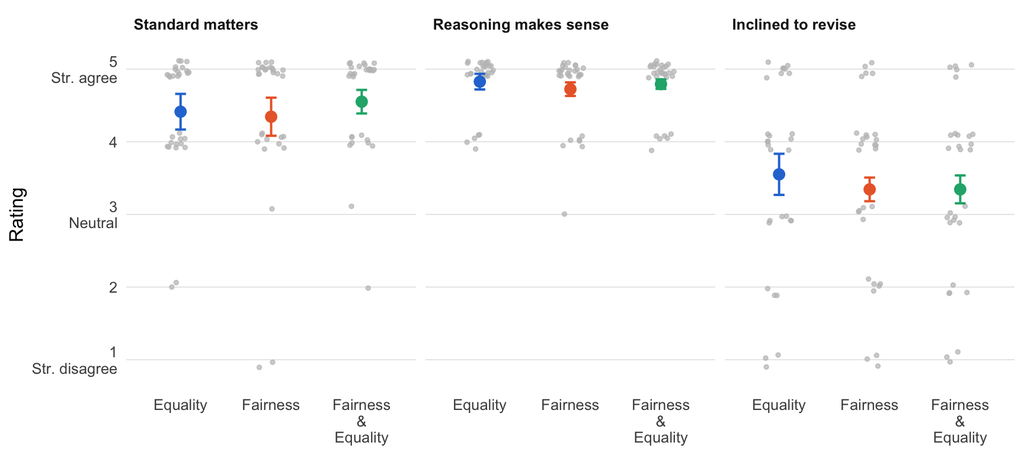

Figure 3: Mean ratings with 95% within-subject confidence intervals (Cousineau–Morey). Small grey points are individual participants.

```r
# Cousineau-Morey within-subject CI
k <- nlevels(long$advice)
ws <- long |>
  group_by(item, id) |> mutate(pmean = mean(score)) |>
  group_by(item) |> mutate(norm = score - pmean + mean(score)) |>
  group_by(item, advice) |>
  summarise(mean = mean(score), n = n(),
            se = sd(norm) / sqrt(n) * sqrt(k / (k - 1)),
            .groups = "drop") |>
  mutate(ci = qt(.975, n - 1) * se)

ggplot(ws, aes(advice, mean, colour = advice)) +
  geom_jitter(data = long, aes(y = score), width = 0.15, height = 0.12,
              colour = "grey75", size = 1, alpha = 0.7) +
  geom_errorbar(aes(ymin = mean - ci, ymax = mean + ci), width = 0.12, linewidth = 0.7) +
  geom_point(size = 3) +
  facet_wrap(~ item) +
  scale_colour_manual(values = pal_adv, guide = "none") +
  scale_y_continuous(breaks = 1:5, limits = c(0.8, 5.2),
                     labels = c("1\nStr. disagree", "2", "3\nNeutral", "4", "5\nStr. agree")) +
  scale_x_discrete(labels = scales::label_wrap(10)) +
  labs(x = NULL, y = "Rating")
```

## 6 Do ratings differ between the advice versions?

The primary tests are non-parametric (ordinal 5-point items); the mixed models are reported as robustness checks.

### 6.1 Friedman tests (omnibus, per item)

```r
wide_item <- function(it) {
  long |> filter(item == it) |>
    select(id, advice, score) |>
    pivot_wider(names_from = advice, values_from = score) |>
    drop_na()
}

friedman_tbl <- map(levels(long$item), \(it) {
  w <- wide_item(it)
  m <- as.matrix(w[, -1])
  ft <- friedman.test(m)
  tibble(item = it, n = nrow(m), chi2 = unname(ft$statistic), df = unname(ft$parameter),
         p = ft$p.value, kendall_W = unname(ft$statistic) / (nrow(m) * (ncol(m) - 1)))
}) |> list_rbind()

friedman_tbl |> kable(digits = c(0, 0, 2, 0, 3, 3),
                      col.names = c("Item", "n", "χ²", "df", "p", "Kendall's W"))
```

| Item | n | χ² | df | p | Kendall’s W |
| --- | --- | --- | --- | --- | --- |
| Standard matters | 29 | 1.75 | 2 | 0.417 | 0.030 |
| Reasoning makes sense | 29 | 2.80 | 2 | 0.247 | 0.048 |
| Inclined to revise | 29 | 3.13 | 2 | 0.209 | 0.054 |

### 6.2 Pairwise comparisons

Wilcoxon signed-rank tests. *r* = Z/√n (matched-pairs effect size); *d<sub>z</sub>* = mean difference / SD of differences. “A > B” / “A < B” counts the participants who rated A higher / lower than B.

```r
pairwise_tbl <- map(levels(long$item), \(it) {
  w <- wide_item(it)
  prs <- combn(levels(long$advice), 2, simplify = FALSE)
  map(prs, \(pr) {
    a <- w[[pr[1]]]; b <- w[[pr[2]]]; dif <- a - b
    wt <- suppressWarnings(wilcox.test(a, b, paired = TRUE, exact = FALSE, correct = TRUE))
    z  <- if (all(dif == 0)) 0 else qnorm(wt$p.value / 2) * -sign(median(dif[dif != 0]))
    tibble(item = it, comparison = paste(pr[1], "vs", pr[2]), n = length(dif),
           mean_diff = mean(dif),
           a_higher = sum(dif > 0), b_higher = sum(dif < 0), ties = sum(dif == 0),
           p = if (all(dif == 0)) 1 else wt$p.value,
           r = z / sqrt(length(dif)),
           dz = if (sd(dif) > 0) mean(dif) / sd(dif) else 0)
  }) |> list_rbind()
}) |> list_rbind() |>
  group_by(item) |> mutate(p_holm = p.adjust(p, "holm")) |> ungroup() |>
  relocate(p_holm, .after = p)

pairwise_tbl |>
  kable(digits = c(0, 0, 0, 2, 0, 0, 0, 3, 3, 2, 2),
        col.names = c("Item", "Comparison", "n", "Mean diff (A−B)", "A > B", "A < B",
                      "Ties", "p", "p (Holm)", "r", "dz"))
```

| Item | Comparison | n | Mean diff (A−B) | A > B | A < B | Ties | p | p (Holm) | r | dz |
| --- | --- | --- | --- | --- | --- | --- | --- | --- | --- | --- |
| Standard matters | Equality vs Fairness | 29 | 0.07 | 4 | 3 | 22 | 0.792 | 0.792 | 0.05 | 0.07 |
| Standard matters | Equality vs Fairness & Equality | 29 | -0.14 | 2 | 4 | 23 | 0.374 | 0.748 | -0.17 | -0.20 |
| Standard matters | Fairness vs Fairness & Equality | 29 | -0.21 | 0 | 3 | 26 | 0.174 | 0.521 | -0.25 | -0.27 |
| Reasoning makes sense | Equality vs Fairness | 29 | 0.10 | 4 | 1 | 24 | 0.233 | 0.699 | 0.22 | 0.25 |
| Reasoning makes sense | Equality vs Fairness & Equality | 29 | 0.03 | 2 | 1 | 26 | 0.773 | 0.773 | 0.05 | 0.11 |
| Reasoning makes sense | Fairness vs Fairness & Equality | 29 | -0.07 | 0 | 2 | 27 | 0.346 | 0.699 | -0.18 | -0.27 |
| Inclined to revise | Equality vs Fairness | 29 | 0.21 | 7 | 3 | 19 | 0.266 | 0.798 | 0.21 | 0.23 |
| Inclined to revise | Equality vs Fairness & Equality | 29 | 0.21 | 8 | 3 | 18 | 0.336 | 0.798 | 0.18 | 0.21 |
| Inclined to revise | Fairness vs Fairness & Equality | 29 | 0.00 | 3 | 3 | 23 | 1.000 | 1.000 | 0.00 | 0.00 |

### 6.3 Linear mixed model (robustness)

`score ~ advice * item + (1 | participant)`; pairwise contrasts of advice within each item via `emmeans` (adjusted).

```r
lmm <- lmer(score ~ advice * item + (1 | id), data = long)
anova(lmm) |> as.data.frame() |> kable(digits = 3)
```

|  | Sum Sq | Mean Sq | NumDF | DenDF | F value | Pr(>F) |
| --- | --- | --- | --- | --- | --- | --- |
| advice | 0.743 | 0.372 | 2 | 224 | 0.562 | 0.571 |
| item | 88.054 | 44.027 | 2 | 224 | 66.594 | 0.000 |
| advice:item | 0.889 | 0.222 | 4 | 224 | 0.336 | 0.853 |

```r
emm <- emmeans(lmm, ~ advice | item)
pairs(emm, adjust = "tukey") |> as.data.frame() |>
  kable(digits = 3)
```

| contrast | item | estimate | SE | df | t.ratio | p.value |
| --- | --- | --- | --- | --- | --- | --- |
| Equality - Fairness | Standard matters | 0.069 | 0.214 | 224 | 0.323 | 0.944 |
| Equality - Fairness & Equality | Standard matters | -0.138 | 0.214 | 224 | -0.646 | 0.795 |
| Fairness - Fairness & Equality | Standard matters | -0.207 | 0.214 | 224 | -0.969 | 0.597 |
| Equality - Fairness | Reasoning makes sense | 0.103 | 0.214 | 224 | 0.484 | 0.879 |
| Equality - Fairness & Equality | Reasoning makes sense | 0.034 | 0.214 | 224 | 0.161 | 0.986 |
| Fairness - Fairness & Equality | Reasoning makes sense | -0.069 | 0.214 | 224 | -0.323 | 0.944 |
| Equality - Fairness | Inclined to revise | 0.207 | 0.214 | 224 | 0.969 | 0.597 |
| Equality - Fairness & Equality | Inclined to revise | 0.207 | 0.214 | 224 | 0.969 | 0.597 |
| Fairness - Fairness & Equality | Inclined to revise | 0.000 | 0.214 | 224 | 0.000 | 1.000 |

### 6.4 Ordinal mixed models (robustness)

Cumulative-link mixed models per item: `score ~ advice + (1 | participant)`. Coefficients are log-odds of a higher rating relative to the reference advice (Equality). With small samples or little variation these models may not converge; failures are reported instead of stopping the render.

```r
clmm_tbl <- map(levels(long$item), \(it) {
  dd <- long |> filter(item == it) |> mutate(y = factor(score, levels = 1:5, ordered = TRUE))
  fit <- tryCatch(ordinal::clmm(y ~ advice + (1 | id), data = dd, nAGQ = 5),
                  error = function(e) e)
  if (inherits(fit, "error")) {
    return(tibble(item = it, term = NA, estimate = NA, se = NA, p = NA,
                  note = paste("Model failed:", conditionMessage(fit))))
  }
  co <- summary(fit)$coefficients
  co <- co[str_detect(rownames(co), "^advice"), , drop = FALSE]
  tibble(item = it, term = str_remove(rownames(co), "^advice"),
         estimate = co[, 1], se = co[, 2], p = co[, 4],
         OR = exp(co[, 1]), note = "")
}) |> list_rbind()

clmm_tbl |> kable(digits = 3)
```

| item | term | estimate | se | p | OR | note |
| --- | --- | --- | --- | --- | --- | --- |
| Standard matters | Fairness | -0.097 | 0.715 | 0.892 | 0.907 |  |
| Standard matters | Fairness & Equality | 0.675 | 0.723 | 0.350 | 1.965 |  |
| Reasoning makes sense | Fairness | -2.942 | 1.699 | 0.083 | 0.053 |  |
| Reasoning makes sense | Fairness & Equality | -1.143 | 1.563 | 0.464 | 0.319 |  |
| Inclined to revise | Fairness | -0.766 | 0.598 | 0.200 | 0.465 |  |
| Inclined to revise | Fairness & Equality | -0.808 | 0.599 | 0.177 | 0.446 |  |

## 7 Participant-level patterns

The three responses give the same recommendation and nearly identical justifications, so an important pretest question is whether participants **differentiate** between them at all.

```r
diff_tbl <- long |>
  group_by(item, id) |>
  summarise(identical = n_distinct(score) == 1, range = max(score) - min(score),
            .groups = "drop") |>
  group_by(item) |>
  summarise(`% identical ratings across all versions` = 100 * mean(identical),
            `Mean within-person range` = mean(range),
            .groups = "drop")

all_same <- long |> group_by(id) |>
  summarise(same = all(tapply(score, item, \(x) n_distinct(x) == 1))) |>
  summarise(pct = 100 * mean(same)) |> pull(pct)

diff_tbl |> kable(digits = 1, col.names = c("Item", "% identical ratings across all versions",
                                           "Mean within-person range (points)"))
```

| Item | % identical ratings across all versions | Mean within-person range (points) |
| --- | --- | --- |
| Standard matters | 72.4 | 0.4 |
| Reasoning makes sense | 82.8 | 0.2 |
| Inclined to revise | 58.6 | 0.6 |

44.8% of participants gave exactly the same ratings to all versions on **every** item.

```r
pref <- long |>
  group_by(id, advice) |> summarise(m = mean(score), .groups = "drop") |>
  group_by(id) |>
  summarise(best = if (sum(m == max(m)) > 1) "Tie" else as.character(advice[which.max(m)]),
            .groups = "drop") |>
  count(best) |> mutate(pct = 100 * n / sum(n)) |>
  arrange(desc(n))
pref |> kable(digits = 1, col.names = c("Highest-rated version", "n", "%"))
```

Table 2: Which version does each participant rate highest? Based on the mean of the three items; ties are shown separately.

| Highest-rated version | n | % |
| --- | --- | --- |
| Tie | 21 | 72.4 |
| Equality | 6 | 20.7 |
| Fairness & Equality | 2 | 6.9 |

## 8 Relationships between the items

Spearman correlations between the three items, computed separately for each advice version. If “standard matters” and “reasoning makes sense” correlate strongly with “inclined to revise”, the first two may act as mechanisms for the persuasiveness of the advice.

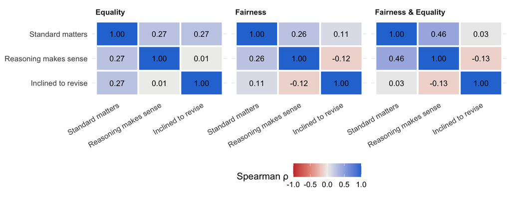

Figure 4

```r
cors <- long |>
  select(id, advice, item, score) |>
  pivot_wider(names_from = item, values_from = score) |>
  group_by(advice) |>
  group_modify(\(df, key) {
    m <- suppressWarnings(cor(df[, levels(long$item)], method = "spearman", use = "pairwise"))
    as_tibble(m, rownames = "item1") |> pivot_longer(-item1, names_to = "item2", values_to = "rho")
  }) |> ungroup() |>
  mutate(item1 = factor(item1, levels(long$item)), item2 = factor(item2, rev(levels(long$item))))

ggplot(cors, aes(item1, item2, fill = rho)) +
  geom_tile(colour = "white", linewidth = 1) +
  geom_text(aes(label = ifelse(is.na(rho), "–", sprintf("%.2f", rho))), size = 3.5) +
  facet_wrap(~ advice) +
  scale_fill_gradient2(low = "#c73a39", mid = "#f0efec", high = "#2a78d6",
                       limits = c(-1, 1), na.value = "grey95", name = "Spearman ρ") +
  labs(x = NULL, y = NULL) +
  theme(axis.text.x = element_text(angle = 30, hjust = 1), panel.grid = element_blank())
```

## 9 Order effects

The advice blocks were presented in random order (Qualtrics block randomiser `FL_17`). The order is only in the data if *“Export randomized viewing order”* is ticked when downloading from Qualtrics (a column like `FL_17_DO`). If present, this section tests whether the position (1st, 2nd, 3rd) affected the ratings.

```r
do_col <- str_subset(names(d_clean), "^FL_\\d+_DO$")
do_col <- do_col[map_lgl(do_col, \(cc) any(str_detect(d_clean[[cc]], paste(names(block_to_advice), collapse = "|")), na.rm = TRUE))]

if (length(do_col) == 0) {
  cat("No display-order column found in this export -> order effects cannot be tested.\n",
      "Tip: in Qualtrics > Data & Analysis > Export, tick 'Export randomized viewing order'.\n")
} else {
  ord <- d_clean |>
    select(ResponseId, order = all_of(do_col[1])) |>
    mutate(order = str_split(order, "\\|")) |>
    unnest_longer(order, indices_to = "position") |>
    mutate(advice_code = block_to_advice[str_trim(order)]) |>
    filter(!is.na(advice_code))
  long_ord <- long |> left_join(ord |> select(ResponseId, advice_code, position),
                                by = c("ResponseId", "advice_code"))
  long_ord |> group_by(item, position) |>
    summarise(mean = mean(score), sd = sd(score), n = n(), .groups = "drop") |>
    kable(digits = 2) |> print()
  lmm_ord <- lmer(score ~ advice * item + factor(position) + (1 | id), data = long_ord)
  anova(lmm_ord) |> as.data.frame() |> kable(digits = 3) |> print()
}
```

```
No display-order column found in this export -> order effects cannot be tested.
 Tip: in Qualtrics > Data & Analysis > Export, tick 'Export randomized viewing order'.
```

## 10 Planning the main study

Observed paired effect sizes (*d<sub>z</sub>*) from the pretest and the number of participants a **within-subject** paired *t*-test would need for 80% power (α = .05, two-sided) to detect them. Pretest effect sizes are imprecise with small samples; treat these as rough guidance only.

```r
power_tbl <- pairwise_tbl |>
  select(item, comparison, dz) |>
  mutate(N_needed_80 = map_dbl(dz, \(e) {
    if (is.na(e) || abs(e) < 0.02) return(NA_real_)
    ceiling(power.t.test(delta = abs(e), sd = 1, sig.level = .05, power = .80,
                         type = "paired")$n)
  }))
power_tbl |> kable(digits = 2, col.names = c("Item", "Comparison", "Observed dz", "N for 80% power"))
```

| Item | Comparison | Observed dz | N for 80% power |
| --- | --- | --- | --- |
| Standard matters | Equality vs Fairness | 0.07 | 1762 |
| Standard matters | Equality vs Fairness & Equality | -0.20 | 201 |
| Standard matters | Fairness vs Fairness & Equality | -0.27 | 112 |
| Reasoning makes sense | Equality vs Fairness | 0.25 | 125 |
| Reasoning makes sense | Equality vs Fairness & Equality | 0.11 | 702 |
| Reasoning makes sense | Fairness vs Fairness & Equality | -0.27 | 112 |
| Inclined to revise | Equality vs Fairness | 0.23 | 151 |
| Inclined to revise | Equality vs Fairness & Equality | 0.21 | 178 |
| Inclined to revise | Fairness vs Fairness & Equality | 0.00 | NA |

## 11 Summary of key numbers

```r
best <- desc |> group_by(item) |> slice_max(mean, n = 1, with_ties = TRUE) |>
  summarise(top = paste(advice, collapse = " / "), mean = first(mean), .groups = "drop")

tibble(
  Item = friedman_tbl$item,
  `Highest mean` = best$top[match(friedman_tbl$item, best$item)],
  `Friedman p` = friedman_tbl$p,
  `Kendall's W` = friedman_tbl$kendall_W,
  `Significant pairs (Holm p < .05)` = map_chr(friedman_tbl$item, \(it) {
    s <- pairwise_tbl |> filter(item == it, p_holm < .05)
    if (nrow(s) == 0) "none" else paste(s$comparison, collapse = "; ")
  })
) |> kable(digits = 3)
```

| Item | Highest mean | Friedman p | Kendall’s W | Significant pairs (Holm p < .05) |
| --- | --- | --- | --- | --- |
| Standard matters | Fairness & Equality | 0.417 | 0.030 | none |
| Reasoning makes sense | Equality | 0.247 | 0.048 | none |
| Inclined to revise | Equality | 0.209 | 0.054 | none |

**Notes**